# IODS course project

# Chapter 5: Dimensionality reduction techniques

*In this chapter, we will practice dimensionality reduction techniques with example data.*

```r
# read in the data
human <- read.csv("C:/Users/koivusus/IODS/IODS-project_new/data/human.csv")

# inspect the data
head(human)
```

```
##   X     Country edu_ratio labo_ratio exp_educ exp_life   gni mort_ratio
## 1 1      Norway 1.0072389  0.8908297     17.5     81.6 64992          4
## 2 2   Australia 0.9968288  0.8189415     20.2     82.4 42261          6
## 3 3 Switzerland 0.9834369  0.8251001     15.8     83.0 56431          6
## 4 4     Denmark 0.9886128  0.8840361     18.7     80.2 44025          5
## 5 5 Netherlands 0.9690608  0.8286119     17.9     81.6 45435          6
## 6 6     Germany 0.9927835  0.8072289     16.5     80.9 43919          7
##   birth_rate parliam_perc
## 1        7.8         39.6
## 2       12.1         30.5
## 3        1.9         28.5
## 4        5.1         38.0
## 5        6.2         36.9
## 6        3.8         36.9
```

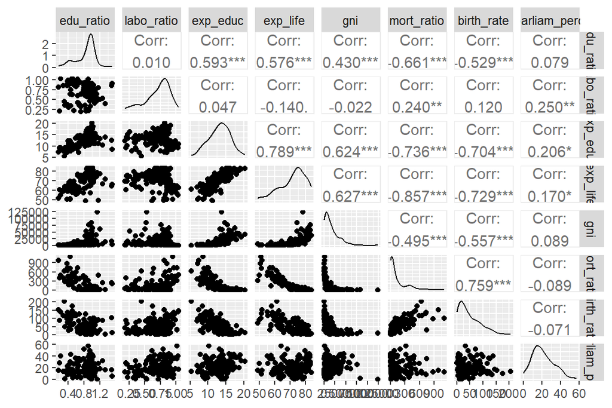

```r
# remove X column
human <- dplyr::select(human, -X)

# move the country names to rownames
library(tibble)
human1 <- column_to_rownames(human, "Country")

# show a graphical overview
library(GGally)
ggpairs(human1, progress = FALSE)
```

```r
# show summaries
summary(human1)
```

```
##    edu_ratio        labo_ratio        exp_educ        exp_life
##  Min.   :0.1717   Min.   :0.1857   Min.   : 5.40   Min.   :49.00
##  1st Qu.:0.7264   1st Qu.:0.5984   1st Qu.:11.25   1st Qu.:66.30
##  Median :0.9375   Median :0.7535   Median :13.50   Median :74.20
##  Mean   :0.8529   Mean   :0.7074   Mean   :13.18   Mean   :71.65
##  3rd Qu.:0.9968   3rd Qu.:0.8535   3rd Qu.:15.20   3rd Qu.:77.25
##  Max.   :1.4967   Max.   :1.0380   Max.   :20.20   Max.   :83.50
##       gni           mort_ratio       birth_rate      parliam_perc
##  Min.   :   581   Min.   :   1.0   Min.   :  0.60   Min.   : 0.00
##  1st Qu.:  4198   1st Qu.:  11.5   1st Qu.: 12.65   1st Qu.:12.40
##  Median : 12040   Median :  49.0   Median : 33.60   Median :19.30
##  Mean   : 17628   Mean   : 149.1   Mean   : 47.16   Mean   :20.91
##  3rd Qu.: 24512   3rd Qu.: 190.0   3rd Qu.: 71.95   3rd Qu.:27.95
##  Max.   :123124   Max.   :1100.0   Max.   :204.80   Max.   :57.50
```

Let’s perform a principal component analysis (PCA) on the raw (non-standardized) human data, and show the variability captured by the principal components in percentages.

Let’s draw a biplot displaying the observations by the first two principal components (PC1 coordinate in x-axis, PC2 coordinate in y-axis), along with arrows representing the original variables.

```r
# perform principal component analysis (with the SVD method)
pca_human1 <- prcomp(human1)

# save summary in an object
s <- summary(pca_human1)

# show variability captured by the principal components as rounded percentanges of variance captured by each PC
pca_pr <- round(1*s$importance[2, ], digits = 5)

# print out the percentages of variance
print(pca_pr)
```

```
##    PC1    PC2    PC3    PC4    PC5    PC6    PC7    PC8
## 0.9999 0.0001 0.0000 0.0000 0.0000 0.0000 0.0000 0.0000
```

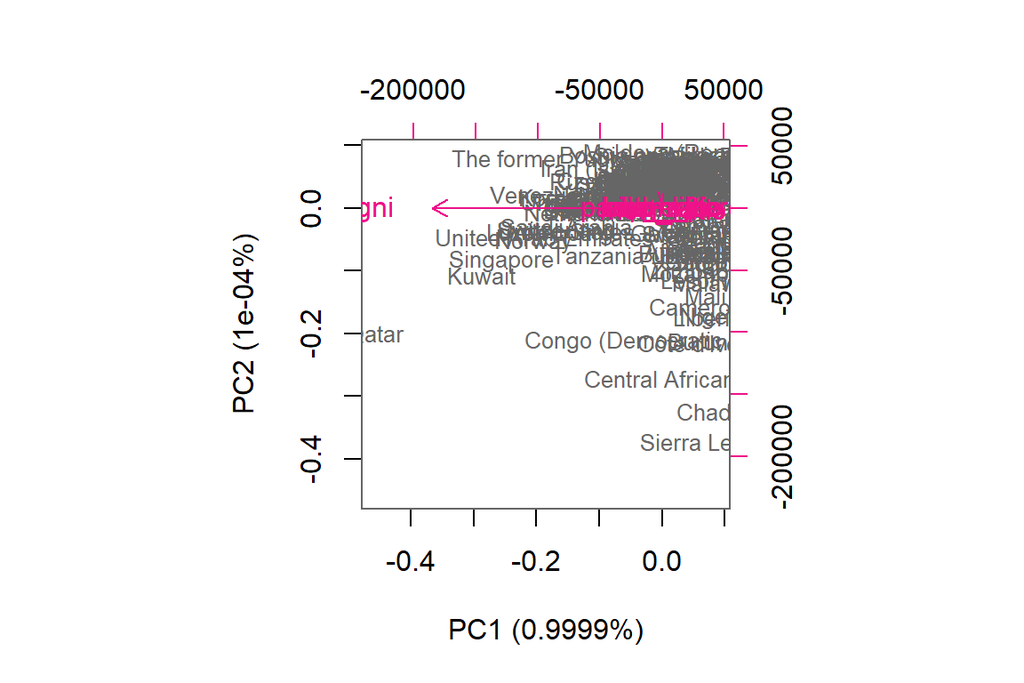

```r
# create object pc_lab to be used as axis labels
pc_lab <- paste0(names(pca_pr), " (", pca_pr, "%)")

# draw a biplot
biplot(pca_human1, cex = c(0.8, 1), col = c("grey40", "deeppink2"), xlab = pc_lab[1], ylab = pc_lab[2])
```

Let’s standardize the variables in the human data and repeat the analysis.

Looks like the results from raw data vs. standardized data differ from each other quite a lot. In the raw data, the first component takes almost all of the variation, whereas in the standardized data, the variation is split between multiple components, with the first one covering c. 54 % of variation.

The variables that are grouped to the component 1 are

- Maternal Mortality,
- Life Expectancy,
- Education Expectancy,
- Adolescent Birth Rate,

whereas variables grouped to the component 2 are

- Labour Force Participation Rate female / male ratio,
- Percent Representation in Parliament (Female).

Thus, the PCA seems to group variables related to individuals life (PC1) and variables related to society (PC2).

```r
# standardize the variables
human_std <- scale(human1)

# perform principal component analysis (with the SVD method)
pca_human_std <- prcomp(human_std)

# save summary in an object
s_std <- summary(pca_human_std)

# show variability captured by the principal components as rounded percentanges of variance captured by each PC
pca_pr_std <- round(1*s_std$importance[2, ], digits = 5)

# print out the percentages of variance
print(pca_pr_std)
```

```
##     PC1     PC2     PC3     PC4     PC5     PC6     PC7     PC8
## 0.53605 0.16237 0.09571 0.07583 0.05477 0.03595 0.02634 0.01298
```

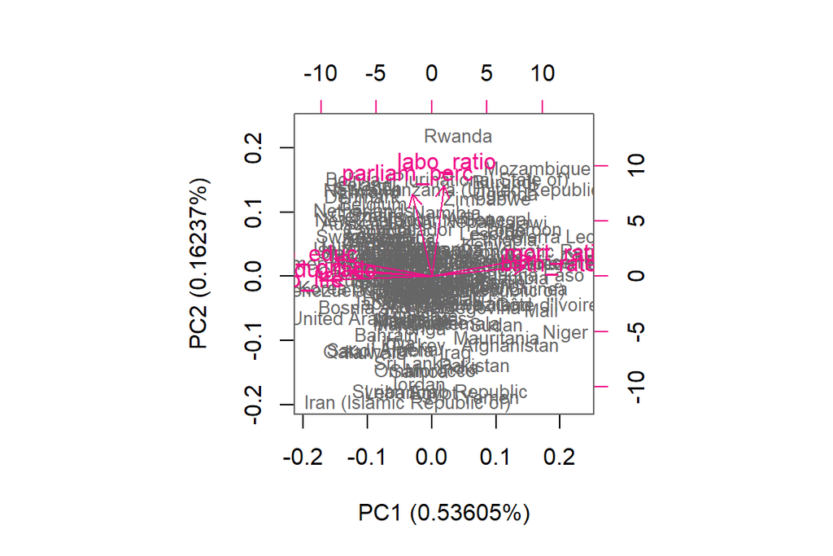

```r
# create object pc_lab to be used as axis labels
pc_lab_std <- paste0(names(pca_pr_std), " (", pca_pr_std, "%)")

# draw a biplot
biplot(pca_human_std, cex = c(0.8, 1), col = c("grey40", "deeppink2"), xlab = pc_lab_std[1], ylab = pc_lab_std[2])
```

Let’s download the tea data from the FactoMineR package and convert its character variables to factors. It is a questionnaire on tea: 300 individuals were asked how they drink tea and what are their product’s perception. In addition, some personal details were asked.

```r
# load the tea dataset and convert its character variables to factors
tea <- read.csv("https://raw.githubusercontent.com/KimmoVehkalahti/Helsinki-Open-Data-Science/master/datasets/tea.csv", stringsAsFactors = TRUE)
```

Let’s explore the data briefly by looking at the structure and the dimensions of the data, viewing its contents and visualizing it.

```r
# explore structure
str(tea)
```

```
## 'data.frame':    300 obs. of  36 variables:
##  $ breakfast       : Factor w/ 2 levels "breakfast","Not.breakfast": 1 1 2 2 1 2 1 2 1 1 ...
##  $ tea.time        : Factor w/ 2 levels "Not.tea time",..: 1 1 2 1 1 1 2 2 2 1 ...
##  $ evening         : Factor w/ 2 levels "evening","Not.evening": 2 2 1 2 1 2 2 1 2 1 ...
##  $ lunch           : Factor w/ 2 levels "lunch","Not.lunch": 2 2 2 2 2 2 2 2 2 2 ...
##  $ dinner          : Factor w/ 2 levels "dinner","Not.dinner": 2 2 1 1 2 1 2 2 2 2 ...
##  $ always          : Factor w/ 2 levels "always","Not.always": 2 2 2 2 1 2 2 2 2 2 ...
##  $ home            : Factor w/ 2 levels "home","Not.home": 1 1 1 1 1 1 1 1 1 1 ...
##  $ work            : Factor w/ 2 levels "Not.work","work": 1 1 2 1 1 1 1 1 1 1 ...
##  $ tearoom         : Factor w/ 2 levels "Not.tearoom",..: 1 1 1 1 1 1 1 1 1 2 ...
##  $ friends         : Factor w/ 2 levels "friends","Not.friends": 2 2 1 2 2 2 1 2 2 2 ...
##  $ resto           : Factor w/ 2 levels "Not.resto","resto": 1 1 2 1 1 1 1 1 1 1 ...
##  $ pub             : Factor w/ 2 levels "Not.pub","pub": 1 1 1 1 1 1 1 1 1 1 ...
##  $ Tea             : Factor w/ 3 levels "black","Earl Grey",..: 1 1 2 2 2 2 2 1 2 1 ...
##  $ How             : Factor w/ 4 levels "alone","lemon",..: 1 3 1 1 1 1 1 3 3 1 ...
```

[output cut: 22 more lines]

```r
# explore dimensions
dim(tea)
```

```
## [1] 300  36
```